# Part II - Loan Data from Prosper

## by Keren Wang'ombe

## Investigation Overview

## Dataset Overview

> The dataset contains information about loans from Prosper. Prosper is a peer-to-peer lending platform. Borrowers can find competitive rates for personal loans. Loans are funded by investors, not Prosper itself. The dataset contains 81 parameters that needed cleaning before visualisation.

## (Visualization 1)

### Does ProsperRating(Alpha) and ProsperScore affect APR?

> **Rubric Tip**: Provide at least 3 **polished** visualizations to convey key insights. The total number of visualizations in the slideshow shoould be less than 50% of the number of visualizations in the exploratory analysis. For example, if the exploratory analysis (Part I) has 18 visualizations, the slideshow can have (3 - 8) visualizations.

> **Rubric Tip**: Each visualization in the slideshow is associated with **descriptive comments** that accurately depict their purpose and your observation.

> **Rubric Tip**: All plots in the slideshow are appropriate, meaning the plot type, encodings, and transformations are suitable to the underlying data.

> **Rubric Tip**: All plots in the slideshow are polished, meaning all plots have a title, labeled x/y axes (with units), x/y ticks, and legends.

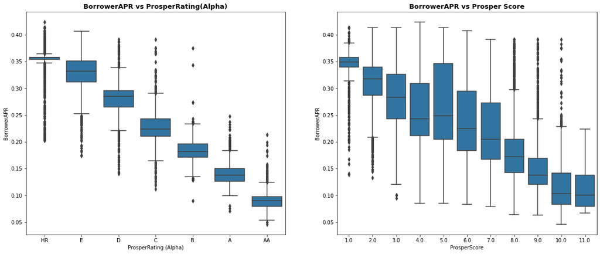

## Visualization 2

### How is the LoanAmount affected by BorrowersAPR

> The relationship between the two is negative, this means as one varible increase the other decreases.In this case when the the Loan amount increases, the BorrowerAPR decreases.

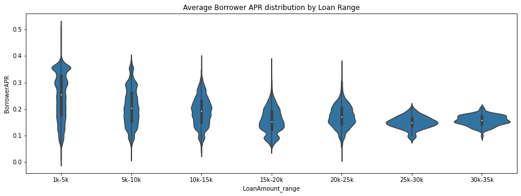

## Visualization 3

### What effect does the loan term have on loan amount and borrower APR?

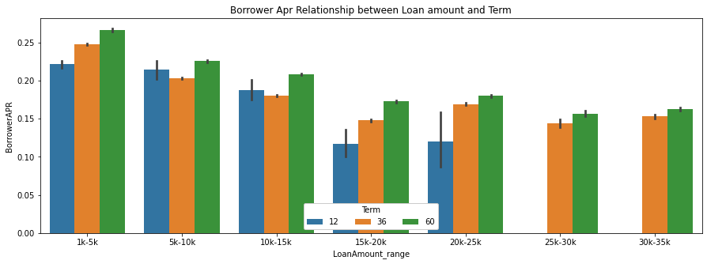